# Stochastic Processes

supplemental code for lecture 10

Sami Cheong

11/18/2020

## Simulation of continuous-time Markov chain

### Service station example

We define the following elements in order to generate a CTMC: $\tilde{P}$ : Embedded DTMC

$q$ : Exponential rates for holding time at each states

$Q$ : Infinitesimal generator, created from the transition rates

```r
## Embedded Markov chain
P_tilde <- rbind(c(0,1,0,0,0),
                 c(4/9,0,5/9,0,0),
                 c(0,4/9,0,5/9,0),
                 c(0,0,4/9,0,5/9),
                 c(0,0,0,1,0))


q_vec <- c(1/4,9/20,9/20,9/20,1/5)


Q <- rbind(c(-1/4,1/4,0,0,0),
          c(1/5,-9/20,1/4,0,0),
          c(0,1/5,-9/20,1/4,0),
          c(0,0,1/5,-9/20,1/4),
          c(0,0,0,1/5,-1/5))




Q <-matrix(Q,nrow = 5,ncol = 5,byrow = FALSE)
```

Here we define a function to simulate the states and transition times based on the information given:

```r
ctmc.sim<- function(state0,P,q, Tend, plotflag = FALSE){
  # Modified from https://rdrr.io/cran/spuRs/src/R/CMCSimulation.R
  # initialize output
  output <-list()
  # set number of states (0,1,2,...n)
  n <- nrow(Q) - 1
  # initialize list of states with input state0
  statehist <- c(state0)
  # initialize list of time stamps with 0
  timehist <- c(0)
  # initialize time step
  time <- 0
  # initialize current state with input state0
  currentstate <- state0
  # counter
  jump <- 2

  while (time < Tend){
    # create accumulated count of holding time
    time <- time + rexp(1, q[currentstate+1])
    # keep track of number of times a state changes
    timehist[jump] <- time
    # sample current state from embedded DTMC matrix
    currentstate <- sample(0:n, 1, prob=P[currentstate+1,])

    statehist[jump] <- currentstate

    jump <- jump + 1
  }

  if (plotflag) {
    plot(timehist, statehist, type="s", xlab="Time", ylab="State",
         ylim=c(0,n), xlim=c(0,Tend), yaxt="n")
    points(timehist, statehist,col=randomColor(),lwd = 2)
    axis(2, at=0:n)
  }
  output$statehist <-statehist
  output$timehist <-timehist
  return(output)
}
```

Let’s take a look at what a realization look like in the first two hours ($[0,120]$)

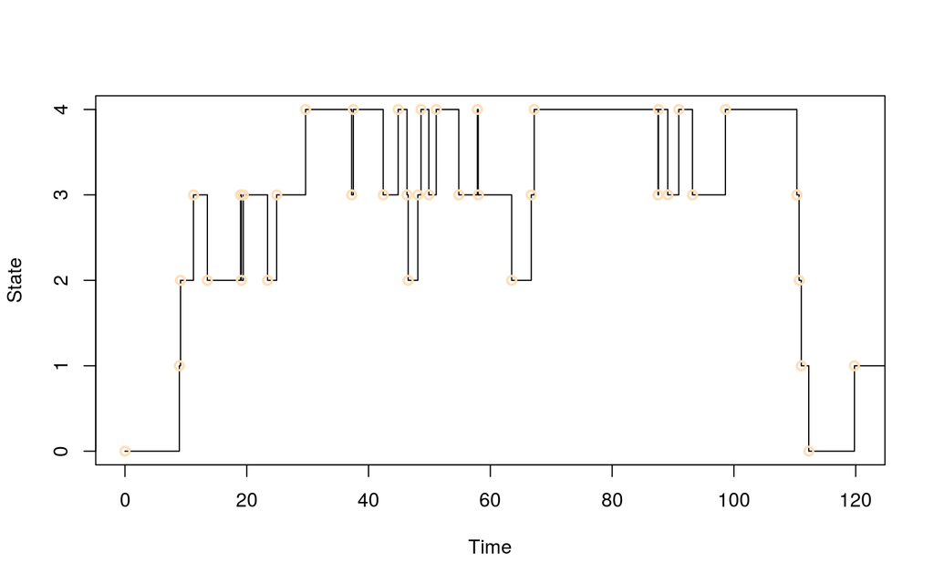

```r
set.seed(692)

ctmc_output2<-ctmc.sim(state0 = 0,P = P_tilde,q = q_vec,Tend = 120,plotflag = TRUE)
```

### The infinitesimal generator

Given the infinitesimal generator matrix $Q$, we can express the transition function $P(t)$ as $P(t) = \exp(Qt),$ which is a matrix exponential.

On the other hand, a matrix exponential term can be approximated by the binomial expansion applied to the matrix as well:

$$e^{Q} = I + Q + \frac{Q^2}{2} + \frac{Q^3}{3!} + \cdots$$

In this example, we can compare the difference between the *exact* value of $e^Q$ versus an approximation using a finite number of terms

```r
matrix_approx<- function(Q,N){

  I <- diag(nrow(Q))
  P<- list()
  PM <-I

  for(i in 1:N){
    PM <-PM+(Q%^%i)/factorial(i)
  }

  return(PM)

}
```

Let’s generate an approximated $e^Q$ with 10 terms and compare that using the package `expm`

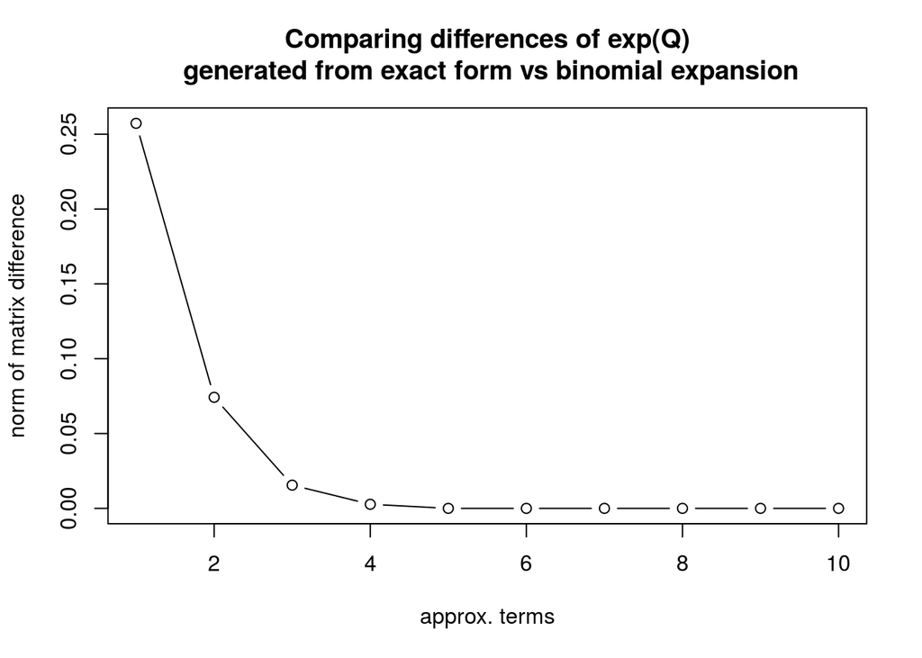

```r
N <-10
diff_norm <-numeric(N)

for(i in 1:N){
  Pt.approx <- matrix_approx(Q,i)

  Pt.exact <- expm::expm(Q)

  D <-round(Pt.approx-Pt.exact,3)

  diff_norm[i]<-norm(D,'2')
}



plot(1:N, diff_norm,
     type ='b',
     xlab = 'approx. terms',
     ylab = 'norm of matrix difference',
     main = 'Comparing differences of exp(Q)\n generated from exact form vs binomial expansion')
```

### Numerically compute the limiting distribution for $P(t)$

The limiting distribution of a CTMC is similar to its discrete counterpart, where it represents the long-term frequency of how often a state is visited. Notice that regardless of initial state, the transition function has the same value for each row.

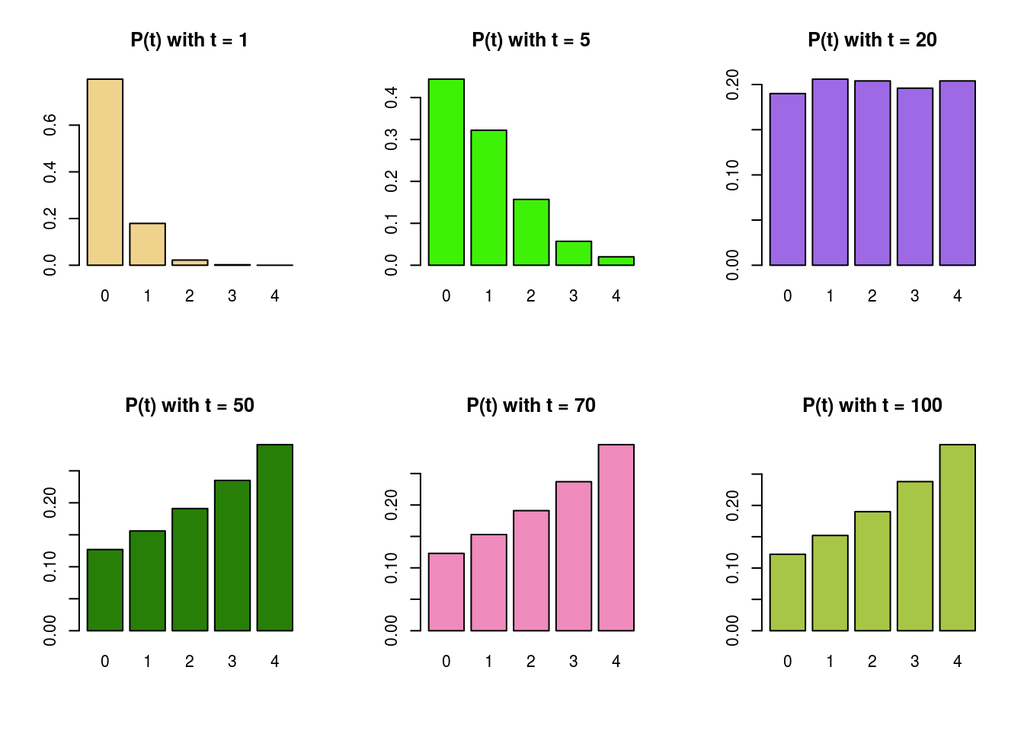

```r
Pt.limit <-function(t,Q,labels = NULL){

  n<-nrow(Q)

  if (is.null(labels)){

    labels <-c(0:(n-1))

  }

  out <- data.frame(expm::expm(t*Q),row.names = labels)

  colnames(out) <- labels

  return(round(out,3))

}


par(mfrow=c(2,3))
t<-c(1,5,20,50,70,100)
for(i in 1:length(t)){
  Pt <-Pt.limit(t[i],Q)
  barplot(height = matrix(Pt[1,],nrow = 1,ncol = 5),
          col = randomColor(),
          names.arg=c("0", "1", "2","3","4"),
          main = paste('P(t) with t =',t[i]))


}
```